# Final Data Analysis Peer Review Assignment

A. de Nevrezé 2022-02-14

# Background

As a statistical consultant working for a real estate investment firm, your task is to develop a model to predict the selling price of a given home in Ames, Iowa. Your employer hopes to use this information to help assess whether the asking price of a house is higher or lower than the true value of the house. If the home is undervalued, it may be a good investment for the firm.

# Training Data and relevant packages

In order to better assess the quality of the model you will produce, the data have been randomly divided into three separate pieces: a training data set, a testing data set, and a validation data set. For now we will load the training data set, the others will be loaded and used later.

```r
load("ames_train.Rdata")
```

Use the code block below to load any necessary packages

```r
library(statsr)
library(dplyr)
library(BAS)
library(ggplot2)
library(gridExtra)
library(MASS)
library(forcats)
library(caret)
```

## Part 1 - Exploratory Data Analysis (EDA)

When you first get your data, it’s very tempting to immediately begin fitting models and assessing how they perform. However, before you begin modeling, it’s absolutely essential to explore the structure of the data and the relationships between the variables in the data set.

Do a detailed EDA of the ames_train data set, to learn about the structure of the data and the relationships between the variables in the data set (refer to Introduction to Probability and Data, Week 2, for a reminder about EDA if needed). Your EDA should involve creating and reviewing many plots/graphs and considering the patterns and relationships you see.

After you have explored completely, submit the three graphs/plots that you found most informative during your EDA process, and briefly explain what you learned from each (why you found each informative).

### 1.1 Data Cleaning

Before beginning with the Exploratory Data Analysis we’ll start by cleaning our training dataset. This is gonna be an initial cleaning so data is clearer and the variables are correctly represented. However, during the model training is probable that more cleaning will be needed.

#### 1.1.1 Variable type conversions

Some variables are **misspecified**: some of them are categorical and need to be converted to integer and vice-versa.

```r
ames_train$area <- as.numeric(ames_train$area)
ames_train$price <- as.numeric(ames_train$price)
ames_train$Lot.Frontage <- as.numeric(ames_train$Lot.Frontage)
ames_train$Lot.Area <- as.numeric(ames_train$Lot.Area)
ames_train$Mas.Vnr.Area <- as.numeric(ames_train$Mas.Vnr.Area)
ames_train$BsmtFin.SF.1 <- as.numeric(ames_train$BsmtFin.SF.1)
ames_train$BsmtFin.SF.2 <- as.numeric(ames_train$BsmtFin.SF.2)
ames_train$Total.Bsmt.SF <- as.numeric(ames_train$Total.Bsmt.SF)
ames_train$MS.SubClass <- as.factor(ames_train$MS.SubClass)
ames_train$Overall.Qual <- as.factor(ames_train$Overall.Qual)
ames_train$Overall.Cond <- as.factor(ames_train$Overall.Cond)
ames_train$X1st.Flr.SF <- as.numeric(ames_train$X1st.Flr.SF)
ames_train$X2nd.Flr.SF <- as.numeric(ames_train$X2nd.Flr.SF)
ames_train$Low.Qual.Fin.SF <- as.numeric(ames_train$Low.Qual.Fin.SF)
ames_train$Garage.Area <- as.numeric(ames_train$Garage.Area)
ames_train$Wood.Deck.SF <- as.numeric(ames_train$Wood.Deck.SF)
ames_train$Open.Porch.SF <- as.numeric(ames_train$Open.Porch.SF)
ames_train$Enclosed.Porch <- as.numeric(ames_train$Enclosed.Porch)
ames_train$X3Ssn.Porch <- as.numeric(ames_train$X3Ssn.Porch)
ames_train$Screen.Porch <- as.numeric(ames_train$Screen.Porch)
ames_train$Pool.Area <- as.numeric(ames_train$Pool.Area)
ames_train$Misc.Val <- as.numeric(ames_train$Misc.Val)
ames_train$Garage.Yr.Blt <- as.integer(ames_train$Garage.Yr.Blt)
```

#### 1.1.2 Undeclared Categories

*Undeclared categories*: There are many features which have undeclared categories which has been left as `N.A` values but instead they have predictive information

```r
ames_train$Alley <- fct_explicit_na(ames_train$Alley, na_level = "None")
ames_train$Bsmt.Qual <- fct_explicit_na(ames_train$Bsmt.Qual, na_level = "None")
ames_train$Bsmt.Cond <- fct_explicit_na(ames_train$Bsmt.Cond, na_level = "None")
ames_train$Bsmt.Exposure <- fct_explicit_na(ames_train$Bsmt.Exposure, na_level = "None")
ames_train$BsmtFin.Type.1 <- fct_explicit_na(ames_train$BsmtFin.Type.1, na_level = "None")
ames_train$BsmtFin.Type.2 <- fct_explicit_na(ames_train$BsmtFin.Type.2, na_level = "None")
ames_train$Fireplace.Qu <- fct_explicit_na(ames_train$Fireplace.Qu, na_level = "None")
ames_train$Garage.Type <- fct_explicit_na(ames_train$Garage.Type, na_level = "None")
ames_train$Garage.Finish <- fct_explicit_na(ames_train$Garage.Finish, na_level = "None")
ames_train$Garage.Type <- fct_explicit_na(ames_train$Garage.Type, na_level = "None")
ames_train$Garage.Qual <- fct_explicit_na(ames_train$Garage.Cond, na_level = "None")
ames_train$Garage.Cond <- fct_explicit_na(ames_train$Garage.Qual, na_level = "None")
ames_train$Pool.QC <- fct_explicit_na(ames_train$Pool.QC, na_level = "None")
ames_train$Fence <- fct_explicit_na(ames_train$Fence, na_level = "None")
ames_train$Misc.Feature <- fct_explicit_na(ames_train$Misc.Feature, na_level = "None")
```

#### 1.1.3 Unsorted Variables

*Unsorted categories*: Some variables are unsorted but should have certain order, so as can be later be decoded properly to integer values when using them in the model.

```r
ames_train$Street <- fct_relevel(ames_train$Street, c("Pave", "Grvl"))
ames_train$Alley <- fct_relevel(ames_train$Alley, c("Pave", "Grvl", "None"))
ames_train$Lot.Shape <- fct_relevel(ames_train$Lot.Shape, c("Reg", "IR1", "IR2", "IR3"))
ames_train$Exter.Qual <- fct_relevel(ames_train$Exter.Qual, c("Ex", "Gd", "TA", "Fa", "Po"))
ames_train$Exter.Cond <- fct_relevel(ames_train$Exter.Cond, c("Ex", "Gd", "TA", "Fa", "Po"))
ames_train$Bsmt.Qual <- fct_relevel(ames_train$Bsmt.Qual,
        c("Ex", "Gd", "TA", "Fa", "Po", "None"))
ames_train$Bsmt.Cond <- fct_relevel(ames_train$Bsmt.Cond,
        c("Ex", "Gd", "TA", "Fa", "Po", "None"))
ames_train$Functional <- fct_relevel(ames_train$Functional, c("Typ", "Min1", "Min2", "Mod",
        "Maj1", "Maj2", "Sev", "Sal"))
ames_train$Fireplace.Qu <- fct_relevel(ames_train$Fireplace.Qu, c("Ex", "Gd", "TA", "Fa",
        "Po", "None"))
ames_train$Garage.Finish <- fct_relevel(ames_train$Garage.Finish, c("Fin", "RFn", "Unf",
        "None"))
ames_train$Garage.Qual <- fct_relevel(ames_train$Garage.Qual, c("Ex", "Gd", "TA", "Fa",
        "Po", "None"))
ames_train$Garage.Cond <- fct_relevel(ames_train$Garage.Cond, c("Ex", "Gd", "TA", "Fa",
        "Po", "None"))
ames_train$Paved.Drive <- fct_relevel(ames_train$Paved.Drive, c("Y", "P", "N"))
ames_train$Pool.QC <- fct_relevel(ames_train$Pool.QC, c("Ex", "Gd", "TA", "Fa", "None"))
ames_train$Fence <- fct_relevel(ames_train$Fence, c("GdPrv", "MnPrv", "GdWo", "MnWo",
        "None"))
ames_train$Bsmt.Exposure <- fct_relevel(ames_train$Bsmt.Exposure,
        c("Gd", "Av", "Mn", "No", "None"))
ames_train$BsmtFin.Type.1 <- fct_relevel(ames_train$BsmtFin.Type.1,
        c("GLQ", "ALQ", "Rec", "BLQ", "LwQ", "Unf", "None"))
ames_train$BsmtFin.Type.2 <- fct_relevel(ames_train$BsmtFin.Type.2,
        c("GLQ", "ALQ", "Rec", "BLQ", "LwQ", "Unf", "None"))
ames_train$Heating.QC <- fct_relevel(ames_train$Heating.QC, c("Ex", "Gd", "TA", "Fa", "Po"))
ames_train$Central.Air <- fct_relevel(ames_train$Central.Air, c("Yes", "No"))
ames_train$Kitchen.Qual <- fct_relevel(ames_train$Kitchen.Qual,
        c("Ex", "Gd", "TA", "Fa", "Po"))
```

### 1.2 EDA - Exploratory Data Analysis

To begin with the Exploratory Data Analysis (EDA), the relationship between price and house location will be analysed. Particularly, the focus will be placed in the neighborhoods. Should the price change given a certain neighborhood?

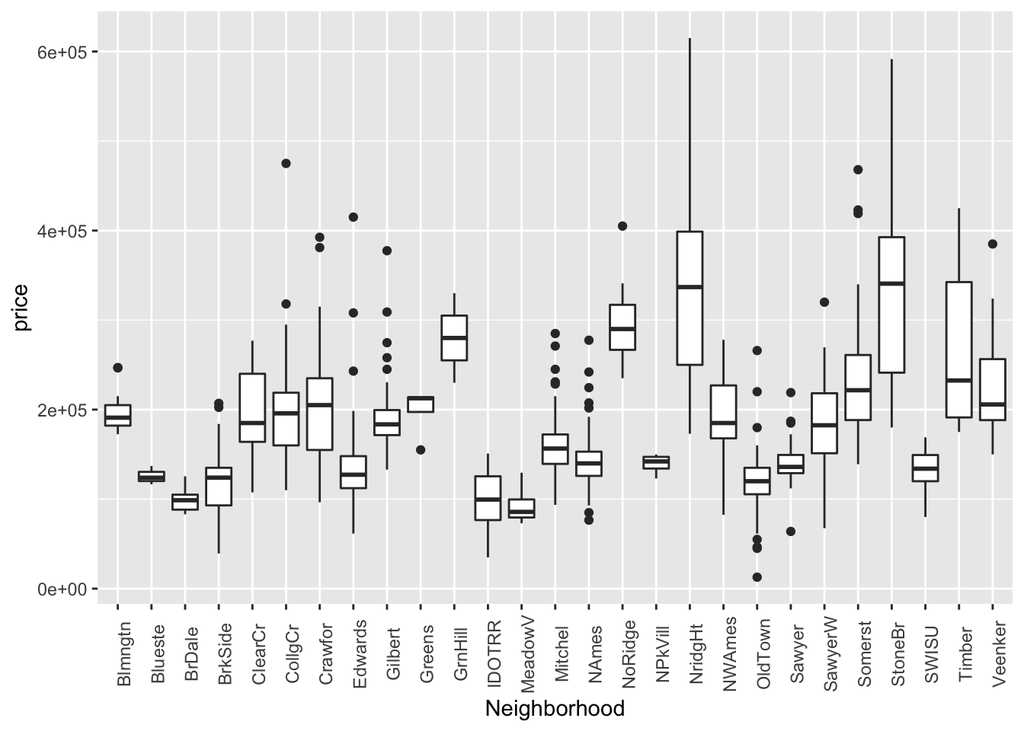

```r
fig <- ggplot(ames_train, aes(x=Neighborhood, y=price)) + geom_boxplot()
fig + theme(axis.text.x = element_text(angle=90))
```

As it can be denoted in the previous graph, there is a high variability between neighborhoods’ prices. Furthermore, the ones more expensive have higher variability based on the interquartile range, which is clearly observed in the boxes height.

Since the median prices for the neighborhoods differ significantly, this variable certainly has predictive value and it’ll be consider in the analysis.

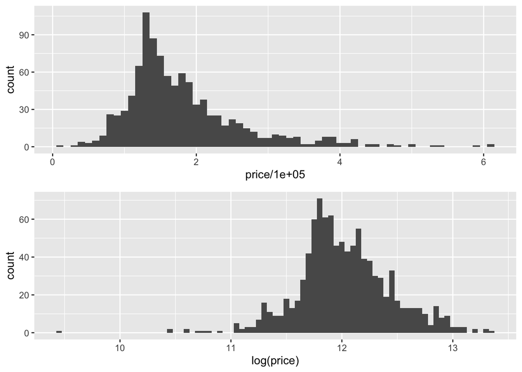

```r
price_plot <- ggplot(ames_train, aes(x=price/1e5)) + geom_histogram(binwidth = .1)
log_price_plot <- ggplot(ames_train, aes(x=log(price))) + geom_histogram( binwidth = .05)
grid.arrange(price_plot, log_price_plot, nrow=2)
```

Our target variable presents a right skew. This can cause some issues if we want to predict prices based on a linear regression fit. However, as soon as the variable is transformed using the `log` of the price, the distribution changes to a normal bell shape. This helps to fit (and predict) in a better way the house prices.

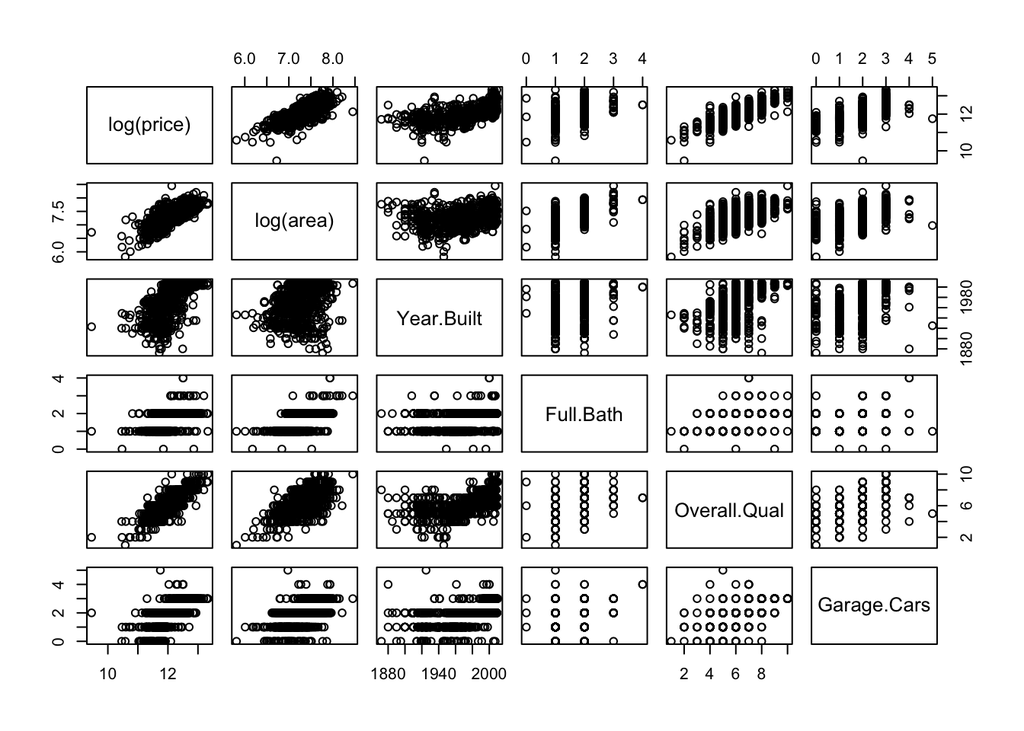

```r
# log(Lot.Area)+log(Lot.Frontage)+X1st.Flr.SF+X2nd.Flr.SF+Total.Bsmt.SF
pairs(log(price) ~ log(area)+Year.Built+Full.Bath+Overall.Qual+Garage.Cars,
      data=ames_train)
```

Finally several variables have been included in a correlation analysis. The selection was not limited to numerical but also categorical features. As it can be seen in the last graphic, there is not much collinearity among them. It’s also true that it’s almost impossible to remove collinearity between variables; as an example, we can observe some dependency between `Garage.Cars` and the house `area`. This is something expected since, larger houses tend to have more garage capacity, in this case, number of cars that can be stored inside.

All area variables are compounding between each other at a certain level. The best descriptor seems to be the log(area) one, since it has a better fit to a linear regression curve. The difference between area and log(area) in how it fits to a regression line is appreciable at a glance so the log transformation was made. Nevertheless, this feature has some outliers as it can easily be seen. Later on the model selection, depending on the feature predictive strength those outliers can be taken out from the sample to increase the model accuracy.

## Part 2 - Development and assessment of an initial model, following a semi-guided process of analysis

### Section 2.1 An Initial Model

In building a model, it is often useful to start by creating a simple, intuitive initial model based on the results of the exploratory data analysis. (Note: The goal at this stage is **not** to identify the “best” possible model but rather to choose a reasonable and understandable starting point. Later you will expand and revise this model to create your final model.

Based on your EDA, select *at most* 10 predictor variables from “ames_train” and create a linear model for `price` (or a transformed version of price) using those variables. Provide the *R code* and the *summary output table* for your model, a *brief justification* for the variables you have chosen, and a *brief discussion* of the model results in context (focused on the variables that appear to be important predictors and how they relate to sales price).

The variables chosen for the baseline model are pretty straightforward. Intuitively we can price a house based on how *big* is it. For so, predictors such as the house `area`, the amount of bathrooms: `Full.Bath` and the amount of cars (`Garage.Cars`) which can be saved inside a house can play as good indicators for this purpose. The year when the house was built (`Year.Built`), together with the property’s overall quality `Overall.Qual` help us to determine how the house is aging. Finally, the house location is also of prime importance. The house might have a luxury style but if it’s located in a bad neighborhood, its relative price compared with other neighborhoods might fall.

```r
baseline_model <- lm(log(price) ~ log(area)+Year.Built+Full.Bath+Overall.Qual+
                     Garage.Cars+Neighborhood,
                     data=ames_train)
summary(baseline_model)
```

```
##
## Call:
## lm(formula = log(price) ~ log(area) + Year.Built + Full.Bath +
##     Overall.Qual + Garage.Cars + Neighborhood, data = ames_train)
##
## Residuals:
##      Min       1Q   Median       3Q      Max
## -1.40718 -0.07651  0.00638  0.08304  0.74130
##
## Coefficients:
##                      Estimate Std. Error t value Pr(>|t|)
## (Intercept)          1.534398   0.917528   1.672 0.094788 .
## log(area)            0.443866   0.026513  16.741  < 2e-16 ***
## Year.Built           0.003333   0.000427   7.805 1.55e-14 ***
## Full.Bath           -0.035287   0.015346  -2.299 0.021691 *
## Overall.Qual2       -0.136614   0.176606  -0.774 0.439387
## Overall.Qual3        0.357868   0.175141   2.043 0.041295 *
## Overall.Qual4        0.406759   0.168628   2.412 0.016045 *
## Overall.Qual5        0.534238   0.167959   3.181 0.001516 **
## Overall.Qual6        0.593936   0.168528   3.524 0.000445 ***
## Overall.Qual7        0.664418   0.169504   3.920 9.49e-05 ***
## Overall.Qual8        0.786937   0.170873   4.605 4.67e-06 ***
## Overall.Qual9        0.972646   0.173918   5.593 2.92e-08 ***
## Overall.Qual10       1.012313   0.181164   5.588 3.00e-08 ***
## Garage.Cars          0.060865   0.010078   6.039 2.21e-09 ***
## NeighborhoodBlueste -0.181730   0.108327  -1.678 0.093749 .
## NeighborhoodBrDale  -0.310832   0.074564  -4.169 3.34e-05 ***
## NeighborhoodBrkSide  0.014465   0.063945   0.226 0.821091
## NeighborhoodClearCr  0.171104   0.070390   2.431 0.015249 *
## NeighborhoodCollgCr  0.036479   0.052770   0.691 0.489555
## NeighborhoodCrawfor  0.203138   0.063045   3.222 0.001315 **
## NeighborhoodEdwards -0.030439   0.057934  -0.525 0.599424
## NeighborhoodGilbert -0.009635   0.055365  -0.174 0.861877
## NeighborhoodGreens   0.069163   0.098250   0.704 0.481633
## NeighborhoodGrnHill  0.466465   0.126318   3.693 0.000234 ***
## NeighborhoodIDOTRR  -0.112173   0.065617  -1.710 0.087679 .
## NeighborhoodMeadowV -0.215083   0.069022  -3.116 0.001887 **
## NeighborhoodMitchel  0.051134   0.057361   0.891 0.372916
## NeighborhoodNAmes    0.044427   0.055874   0.795 0.426735
## NeighborhoodNoRidge  0.124535   0.060021   2.075 0.038264 *
## NeighborhoodNPkVill -0.102971   0.096737  -1.064 0.287394
## NeighborhoodNridgHt  0.151156   0.056212   2.689 0.007290 **
## NeighborhoodNWAmes   0.028391   0.057295   0.496 0.620346
## NeighborhoodOldTown -0.014564   0.063443  -0.230 0.818488
## NeighborhoodSawyer   0.038270   0.057743   0.663 0.507640
## NeighborhoodSawyerW -0.036141   0.055913  -0.646 0.518188
## NeighborhoodSomerst  0.053099   0.053239   0.997 0.318832
## NeighborhoodStoneBr  0.185541   0.063587   2.918 0.003606 **
## NeighborhoodSWISU   -0.003205   0.075581  -0.042 0.966181
## NeighborhoodTimber   0.136501   0.062780   2.174 0.029929 *
## NeighborhoodVeenker  0.070317   0.073334   0.959 0.337872
## ---
## Signif. codes:  0 '***' 0.001 '**' 0.01 '*' 0.05 '.' 0.1 ' ' 1
##
## Residual standard error: 0.1631 on 959 degrees of freedom
##   (1 observation deleted due to missingness)
## Multiple R-squared:  0.8557, Adjusted R-squared:  0.8498
## F-statistic: 145.8 on 39 and 959 DF,  p-value: < 2.2e-16
```

Looking at the baseline model summary results, a relatively high R-squared value can be observed. Even the adjusted one which considers the fact that several variables are included. Notice that this correction has in mind the propensity to have more collinearity as the amount of predictors are increased. Given the *coefficient of determination* ($R^2$) the model explains almost 85% of the target variability. Almost all the variables included have high significance looking at their Pr(>|t|) except for Full.Bath which in general terms have a good capacity to explain price variability. Maybe the predictiveness power of this last variable can be increased should some outliers are removed such as those houses without full baths which might represent very particular selling conditions.

### Section 2.2 Model Selection

Now either using `BAS` or another stepwise selection procedure choose the “best” model you can, using your initial model as your starting point. Try at least two different model selection methods and compare their results. Do they both arrive at the same model or do they disagree? What do you think this means?

To select the best possible model, we will use step-wise elimination. Typically what is used is the backwards elimination process which is stated as follows:

1. Begin with the complete model and choose a metric (R2, adjusted R2, or something else) to evaluate the model. Then compute it for the full/initial model.
2. Remove one variable at a time from the model and record the resulting metric of the new model.
3. Pick the model with the best metric improvement (e.g., the highest increase in adjusted R2 or the lowest AIC) - this is the new “base” model.
4. Repeat steps 2 and 3 until the metric has no more benefit on removing more variables.

For this particular case two methods will be chosen:

The Akaike information criterion (AIC) is a way to estimate the quality of each model relative to each of the other models. If we have k variables and $L$ is the maximum value of the likelihood function of the model, the AIC is given by $AIC=2k−2ln(L)$

The “best model is the one with the minimum AIC. From the equation, we see that the AIC rewards goodness of fit (from the likelihood function), but it also penalizes models that have more features.

The Bayesian Information Criterion (BIC) is similar to the AIC; it is given by $BIC−kln(n)−2ln(L)$

Let’s begin with the AIC model and check which variables has been chosen.

```r
AIC_model <- stepAIC(baseline_model, k = 2)
```

```
## Start:  AIC=-3584.45
## log(price) ~ log(area) + Year.Built + Full.Bath + Overall.Qual +
##     Garage.Cars + Neighborhood
##
##                Df Sum of Sq    RSS     AIC
## <none>                      25.499 -3584.5
## - Full.Bath     1    0.1406 25.639 -3581.0
## - Garage.Cars   1    0.9698 26.469 -3549.2
## - Year.Built    1    1.6199 27.119 -3524.9
## - Neighborhood 26    5.3697 30.869 -3445.5
## - Overall.Qual  9    7.8873 33.386 -3333.2
## - log(area)     1    7.4520 32.951 -3330.3
```

Now let’s take a look to the BIC fitted model.

```r
n = nrow(ames_train)
k_BIC = log(n)
BIC_model <- stepAIC(baseline_model, k = k_BIC)
```

```
## Start:  AIC=-3388.14
## log(price) ~ log(area) + Year.Built + Full.Bath + Overall.Qual +
##     Garage.Cars + Neighborhood
##
##                Df Sum of Sq    RSS     AIC
## - Full.Bath     1    0.1406 25.639 -3389.6
## <none>                      25.499 -3388.1
## - Neighborhood 26    5.3697 30.869 -3376.8
## - Garage.Cars   1    0.9698 26.469 -3357.8
## - Year.Built    1    1.6199 27.119 -3333.5
## - Overall.Qual  9    7.8873 33.386 -3181.1
## - log(area)     1    7.4520 32.951 -3138.9
##
## Step:  AIC=-3389.56
## log(price) ~ log(area) + Year.Built + Overall.Qual + Garage.Cars +
##     Neighborhood
##
##                Df Sum of Sq    RSS     AIC
## <none>                      25.639 -3389.6
## - Neighborhood 26    5.4941 31.134 -3375.2
## - Garage.Cars   1    0.9781 26.618 -3359.1
## - Year.Built    1    1.5006 27.140 -3339.6
## - Overall.Qual  9    8.2028 33.842 -3174.4
## - log(area)     1    8.7058 34.345 -3104.4
```

As can be noticed, the BIC criteria dropped one of the model variales: `Full.Bath`. Generally speaking, AIC is more susceptible to overfitting the data and BIC the opposite. Both of these are true simply because of each metric penalizes free parameters. The AIC is generally better for prediction because it is asymptotically equivalent to cross-validation; BIC is better for explanation since it is asymptotically equivalent to leave-one-out cross-validation (and therefore allows consistent estimation of the underlying data-generating process).

We will continue with the AIC-selected model, but let’s first take a look on a Bayesian approach to select variables to see if we found some differences.

```r
bma_model <- bas.lm(log(price) ~ log(area)+Year.Built+Full.Bath+Overall.Qual+
                     Garage.Cars+Neighborhood,
                     data=ames_train,
                     prior = "BIC",
                     modelprior = uniform())
summary(bma_model)
```

```
##                     P(B != 0 | Y)    model 1       model 2       model 3
## Intercept              1.00000000     1.0000     1.0000000     1.0000000
## log(area)              1.00000000     1.0000     1.0000000     1.0000000
## Year.Built             1.00000000     1.0000     1.0000000     1.0000000
## Full.Bath              0.84999040     1.0000     1.0000000     1.0000000
## Overall.Qual2          0.69006188     1.0000     1.0000000     1.0000000
## Overall.Qual3          0.35088916     0.0000     0.0000000     0.0000000
## Overall.Qual4          0.38599223     0.0000     0.0000000     0.0000000
## Overall.Qual5          0.99767062     1.0000     1.0000000     1.0000000
## Overall.Qual6          0.99915934     1.0000     1.0000000     1.0000000
## Overall.Qual7          0.99985323     1.0000     1.0000000     1.0000000
## Overall.Qual8          0.99999566     1.0000     1.0000000     1.0000000
## Overall.Qual9          0.99999973     1.0000     1.0000000     1.0000000
## Overall.Qual10         0.99999963     1.0000     1.0000000     1.0000000
## Garage.Cars            0.99999991     1.0000     1.0000000     1.0000000
## NeighborhoodBlueste    0.26812126     0.0000     0.0000000     0.0000000
## NeighborhoodBrDale     0.99999990     1.0000     1.0000000     1.0000000
## NeighborhoodBrkSide    0.02404954     0.0000     0.0000000     0.0000000
## NeighborhoodClearCr    0.85838232     1.0000     1.0000000     1.0000000
## NeighborhoodCollgCr    0.02597051     0.0000     0.0000000     0.0000000
## NeighborhoodCrawfor    0.99999513     1.0000     1.0000000     1.0000000
## NeighborhoodEdwards    0.43283841     0.0000     0.0000000     1.0000000
## NeighborhoodGilbert    0.22621117     0.0000     0.0000000     0.0000000
## NeighborhoodGreens     0.02365412     0.0000     0.0000000     0.0000000
## NeighborhoodGrnHill    0.97875022     1.0000     1.0000000     1.0000000
## NeighborhoodIDOTRR     0.98249769     1.0000     1.0000000     1.0000000
## NeighborhoodMeadowV    0.99996301     1.0000     1.0000000     1.0000000
## NeighborhoodMitchel    0.03753563     0.0000     0.0000000     0.0000000
## NeighborhoodNAmes      0.15458211     0.0000     0.0000000     0.0000000
## NeighborhoodNoRidge    0.34758144     0.0000     0.0000000     0.0000000
## NeighborhoodNPkVill    0.08384085     0.0000     0.0000000     0.0000000
## NeighborhoodNridgHt    0.91023151     1.0000     1.0000000     1.0000000
## NeighborhoodNWAmes     0.02384797     0.0000     0.0000000     0.0000000
## NeighborhoodOldTown    0.08929826     0.0000     0.0000000     0.0000000
## NeighborhoodSawyer     0.03127532     0.0000     0.0000000     0.0000000
## NeighborhoodSawyerW    0.61533183     1.0000     0.0000000     1.0000000
## NeighborhoodSomerst    0.03330755     0.0000     0.0000000     0.0000000
## NeighborhoodStoneBr    0.84852854     1.0000     1.0000000     1.0000000
## NeighborhoodSWISU      0.02393681     0.0000     0.0000000     0.0000000
## NeighborhoodTimber     0.37406728     0.0000     0.0000000     0.0000000
```

[output cut: 37 more lines]

```
## NeighborhoodNridgHt     1.0000000     1.0000000
## NeighborhoodNWAmes      0.0000000     0.0000000
## NeighborhoodOldTown     0.0000000     0.0000000
## NeighborhoodSawyer      0.0000000     0.0000000
## NeighborhoodSawyerW     0.0000000     0.0000000
## NeighborhoodSomerst     0.0000000     0.0000000
## NeighborhoodStoneBr     1.0000000     1.0000000
## NeighborhoodSWISU       0.0000000     0.0000000
## NeighborhoodTimber      1.0000000     1.0000000
## NeighborhoodVeenker     0.0000000     0.0000000
## BF                      0.7126016     0.6561991
## PostProbs               0.0092000     0.0085000
## R2                      0.8502000     0.8491000
## dim                    22.0000000    21.0000000
## logmarg             -1712.3503916 -1712.4328499
```

### Section 2.3 Initial Model Residuals

One way to assess the performance of a model is to examine the model’s residuals. In the space below, create a residual plot for your preferred model from above and use it to assess whether your model appears to fit the data well. Comment on any interesting structure in the residual plot (trend, outliers, etc.) and briefly discuss potential implications it may have for your model and inference / prediction you might produce.

Let’s plot the residuals for our base line model which includes the whole set of variables that have been identified as informative.

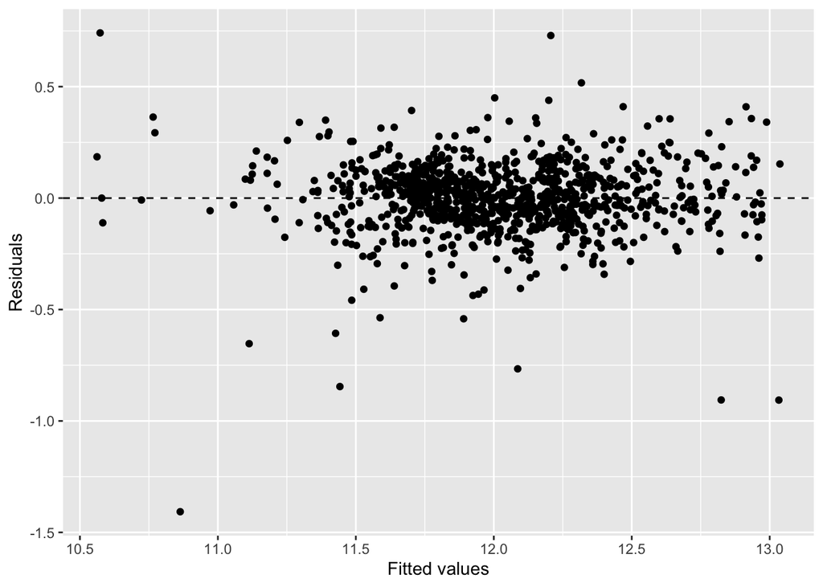

```r
ggplot(data = baseline_model, aes(x = .fitted, y = .resid)) +
  geom_point() +
  geom_hline(yintercept = 0, linetype = "dashed") +
  xlab("Fitted values") +
  ylab("Residuals")
```

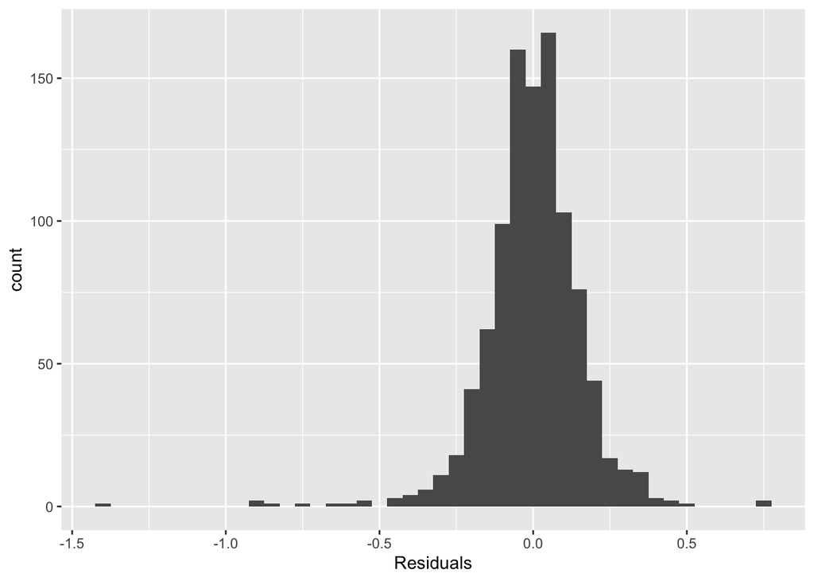

```r
ggplot(data = baseline_model, aes(x = .resid)) +
  geom_histogram(binwidth = .05) +
  xlab("Residuals")
```

There are 2 outliers which needs attention and may have an impact in the regression fit. The first one and most noticeable has a value < -1. This means that this house has been sold at a lower price than the average for similar houses. The second one has a positive residual value, this means that the selling price has been underestimated. Since it’s value doesn’t fall far away from the other residuals, it can be considered in the modelling. Maybe in the other datasets are points similar to this one and having it included helps to model the others.

### Section 2.4 Initial Model RMSE

You can calculate it directly based on the model output. Be specific about the units of your RMSE (depending on whether you transformed your response variable). The value you report will be more meaningful if it is in the original units (dollars).

```r
# Extract Predictions
baseline_predictions <- exp(predict(baseline_model, ames_train))

# Remove unpredicted values
na_values <- which(!complete.cases(baseline_predictions))
ames_train <- ames_train[-c(na_values),]
baseline_predictions <- baseline_predictions[-c(na_values)]

# Extract Residuals
baseline_residuals <- ames_train$price - baseline_predictions

# Calculate RMSE
baseline_rmse <- sqrt(mean(baseline_residuals^2))
baseline_rmse
```

```
## [1] 31992.13
```

Using the `baseline_model`, the squared root of the averaged squared residuals for estimating the house price is of $31,992.13. The lower this value, the better the model predictive power. Since residuals are squared, the RMSE is quite sensitive for outliers. Probably, this value would fall if the outliers mentioned previously are removed.

Let’s take a look to other accuracy measurements to compare the model performance

```r
# Overall performance of original model
postResample(pred=baseline_predictions, obs=ames_train$price)
```

```
##         RMSE     Rsquared          MAE
## 3.199213e+04 8.489922e-01 2.011976e+04
```

### Section 2.5 Overfitting

The process of building a model generally involves starting with an initial model (as you have done above), identifying its shortcomings, and adapting the model accordingly. This process may be repeated several times until the model fits the data reasonably well. However, the model may do well on training data but perform poorly out-of-sample (meaning, on a dataset other than the original training data) because the model is overly-tuned to specifically fit the training data. This is called “overfitting.” To determine whether overfitting is occurring on a model, compare the performance of a model on both in-sample and out-of-sample data sets. To look at performance of your initial model on out-of-sample data, you will use the data set `ames_test`.

```r
load("ames_test.Rdata")
```

Use your model from above to generate predictions for the housing prices in the test data set. Are the predictions significantly more accurate (compared to the actual sales prices) for the training data than the test data? Why or why not? Briefly explain how you determined that (what steps or processes did you use)?

As we did with the training data, it’s important to clean the testing one before applying the model, otherwise it won’t be possible to compare the results and obtain comparable and significant information of the analysis. As this is the same task as was done before the code chunks will be hidden to keep the project report clean.

```r
# Landmark neighborhood is not present in training data :-(
ames_test <- subset(ames_test, Neighborhood!='Landmrk')

# Make predictions
test_predictions <- exp(predict(baseline_model, ames_test))

postResample(pred=test_predictions, obs=ames_test$price)
```

```
##         RMSE     Rsquared          MAE
## 2.805033e+04 8.543819e-01 1.881661e+04
```

Before analyzing the results is important to mention that our training data was not representative, since one of the neighborhoods was not present. For so, that single observation has been dropped. In the future, it will be important to add a complete subset of neighborhoods to the training dataset since the predicted price relies on the neighborhood location.

As it can be seen from the RMSE, the prediction errors are better in the test dataset. This is a good indication of predictiveness performance of the baseline model. The next steps will be related on how to build on top of this baseline model. * * *

## Part 3 Development of a Final Model

Now that you have developed an initial model to use as a baseline, create a final model with *at most* 20 variables to predict housing prices in Ames, IA, selecting from the full array of variables in the dataset and using any of the tools that we introduced in this specialization.

Carefully document the process that you used to come up with your final model, so that you can answer the questions below.

### Section 3.1 Final Model

Provide the summary table for your model.

```r
# Starting from the full variable model and using BIC and linear backward elimination model check if the same model is arrived
full_model <- lm(log(price) ~
                 log(area)+Year.Built+Full.Bath+Overall.Qual+
                 Garage.Cars+Neighborhood+MS.Zoning+MS.SubClass+
                 Street+Land.Slope+Condition.1+Condition.2+
                 Lot.Config+Exterior.1st+Foundation,
                 data=ames_train)

final_model_BEP <- step(full_model, direction = "backward", trace = FALSE)
summary(final_model_BEP)
```

```
##
## Call:
## lm(formula = log(price) ~ log(area) + Year.Built + Overall.Qual +
##     Garage.Cars + Neighborhood + MS.Zoning + MS.SubClass + Land.Slope +
##     Condition.1 + Condition.2 + Exterior.1st + Foundation, data = ames_train)
##
## Residuals:
##      Min       1Q   Median       3Q      Max
## -1.26139 -0.06595  0.00471  0.07416  0.60327
##
## Coefficients:
##                       Estimate Std. Error t value Pr(>|t|)
## (Intercept)          0.1821786  1.1211621   0.162 0.870955
## log(area)            0.4955936  0.0275982  17.957  < 2e-16 ***
## Year.Built           0.0035187  0.0005348   6.580 7.92e-11 ***
## Overall.Qual2        0.0208530  0.1710141   0.122 0.902976
## Overall.Qual3        0.4668390  0.1693146   2.757 0.005946 **
## Overall.Qual4        0.4655194  0.1648237   2.824 0.004841 **
## Overall.Qual5        0.5830265  0.1652300   3.529 0.000439 ***
## Overall.Qual6        0.6419652  0.1663273   3.860 0.000122 ***
## Overall.Qual7        0.6859738  0.1673696   4.099 4.53e-05 ***
## Overall.Qual8        0.7672360  0.1684846   4.554 5.99e-06 ***
## Overall.Qual9        0.9482454  0.1713063   5.535 4.06e-08 ***
## Overall.Qual10       0.9601037  0.1785641   5.377 9.64e-08 ***
## Garage.Cars          0.0459752  0.0097808   4.701 3.00e-06 ***
## NeighborhoodBlueste  0.1114127  0.1081016   1.031 0.302988
## NeighborhoodBrDale   0.0139915  0.0826832   0.169 0.865663
## NeighborhoodBrkSide  0.0693950  0.0673880   1.030 0.303386
## NeighborhoodClearCr  0.1082170  0.0693100   1.561 0.118789
## NeighborhoodCollgCr -0.0192310  0.0514565  -0.374 0.708690
## NeighborhoodCrawfor  0.1439677  0.0602654   2.389 0.017102 *
## NeighborhoodEdwards -0.0494370  0.0561404  -0.881 0.378769
## NeighborhoodGilbert -0.0309942  0.0544570  -0.569 0.569395
## NeighborhoodGreens   0.2006149  0.0909777   2.205 0.027696 *
## NeighborhoodGrnHill  0.5484926  0.1177528   4.658 3.67e-06 ***
## NeighborhoodIDOTRR   0.0296382  0.0730067   0.406 0.684863
## NeighborhoodMeadowV -0.0771499  0.0840977  -0.917 0.359185
## NeighborhoodMitchel  0.0119158  0.0559074   0.213 0.831270
## NeighborhoodNAmes    0.0017378  0.0552243   0.031 0.974904
## NeighborhoodNoRidge  0.1313874  0.0578590   2.271 0.023390 *
```

[output cut: 51 more lines]

```
## Exterior.1stPlywood  0.1906773  0.0515995   3.695 0.000233 ***
## Exterior.1stStucco   0.2281816  0.0615607   3.707 0.000223 ***
## Exterior.1stVinylSd  0.2072781  0.0487735   4.250 2.36e-05 ***
## Exterior.1stWd Sdng  0.1917677  0.0487110   3.937 8.88e-05 ***
## Exterior.1stWdShing  0.1975024  0.0564802   3.497 0.000494 ***
## FoundationCBlock    -0.0085456  0.0224569  -0.381 0.703639
## FoundationPConc      0.0164405  0.0248009   0.663 0.507562
## FoundationSlab      -0.1125506  0.0516494  -2.179 0.029578 *
## FoundationStone      0.1623106  0.0923730   1.757 0.079233 .
## ---
## Signif. codes:  0 '***' 0.001 '**' 0.01 '*' 0.05 '.' 0.1 ' ' 1
##
## Residual standard error: 0.1462 on 911 degrees of freedom
## Multiple R-squared:  0.8899, Adjusted R-squared:  0.8794
## F-statistic: 84.62 on 87 and 911 DF,  p-value: < 2.2e-16
```

Using the BIC elimination process

```r
final_model_BMA <- bas.lm(log(price) ~
                     log(area)+Year.Built+Full.Bath+Overall.Qual+
                     Garage.Cars+Neighborhood+MS.Zoning+MS.SubClass+
                     Street+Land.Slope+Condition.1+Condition.2+
                     Lot.Config+Exterior.1st+Foundation,
                     data=ames_train,
                     prior = "BIC",
                     modelprior = uniform())
summary(final_model_BMA)
```

```
##                     P(B != 0 | Y)    model 1       model 2      model 3
## Intercept             1.000000000     1.0000     1.0000000     1.000000
## log(area)             1.000000000     1.0000     1.0000000     1.000000
## Year.Built            1.000000000     1.0000     1.0000000     1.000000
## Full.Bath             0.027345735     0.0000     0.0000000     0.000000
## Overall.Qual2         0.040771317     0.0000     0.0000000     0.000000
## Overall.Qual3         0.975098531     1.0000     1.0000000     1.000000
## Overall.Qual4         0.976674152     1.0000     1.0000000     1.000000
## Overall.Qual5         0.999943799     1.0000     1.0000000     1.000000
## Overall.Qual6         0.999985000     1.0000     1.0000000     1.000000
## Overall.Qual7         0.999997520     1.0000     1.0000000     1.000000
## Overall.Qual8         0.999999715     1.0000     1.0000000     1.000000
## Overall.Qual9         0.999999998     1.0000     1.0000000     1.000000
## Overall.Qual10        0.999999996     1.0000     1.0000000     1.000000
## Garage.Cars           0.999999498     1.0000     1.0000000     1.000000
## NeighborhoodBlueste   0.018150230     0.0000     0.0000000     0.000000
## NeighborhoodBrDale    0.010878817     0.0000     0.0000000     0.000000
## NeighborhoodBrkSide   0.033626378     0.0000     0.0000000     0.000000
## NeighborhoodClearCr   0.149030295     0.0000     0.0000000     0.000000
## NeighborhoodCollgCr   0.010339279     0.0000     0.0000000     0.000000
## NeighborhoodCrawfor   0.999230550     1.0000     1.0000000     1.000000
## NeighborhoodEdwards   0.975210334     1.0000     1.0000000     1.000000
## NeighborhoodGilbert   0.022517630     0.0000     0.0000000     0.000000
## NeighborhoodGreens    0.029569453     0.0000     0.0000000     0.000000
## NeighborhoodGrnHill   0.999977923     1.0000     1.0000000     1.000000
## NeighborhoodIDOTRR    0.010422114     0.0000     0.0000000     0.000000
## NeighborhoodMeadowV   0.010635489     0.0000     0.0000000     0.000000
## NeighborhoodMitchel   0.009667683     0.0000     0.0000000     0.000000
## NeighborhoodNAmes     0.009065118     0.0000     0.0000000     0.000000
## NeighborhoodNoRidge   0.990724661     1.0000     1.0000000     1.000000
## NeighborhoodNPkVill   0.009104520     0.0000     0.0000000     0.000000
## NeighborhoodNridgHt   0.999927527     1.0000     1.0000000     1.000000
## NeighborhoodNWAmes    0.013615901     0.0000     0.0000000     0.000000
## NeighborhoodOldTown   0.009012755     0.0000     0.0000000     0.000000
## NeighborhoodSawyer    0.011002653     0.0000     0.0000000     0.000000
## NeighborhoodSawyerW   0.030889494     0.0000     0.0000000     0.000000
## NeighborhoodSomerst   0.981733566     1.0000     1.0000000     1.000000
## NeighborhoodStoneBr   0.997944334     1.0000     1.0000000     1.000000
## NeighborhoodSWISU     0.025597634     0.0000     0.0000000     0.000000
## NeighborhoodTimber    0.036415403     0.0000     0.0000000     0.000000
```

[output cut: 145 more lines]

```
## Exterior.1stMetalSd     0.0000000     0.0000000
## Exterior.1stPlywood     0.0000000     0.0000000
## Exterior.1stStucco      0.0000000     0.0000000
## Exterior.1stVinylSd     0.0000000     0.0000000
## Exterior.1stWd Sdng     0.0000000     0.0000000
## Exterior.1stWdShing     0.0000000     0.0000000
## FoundationCBlock        0.0000000     0.0000000
## FoundationPConc         0.0000000     0.0000000
## FoundationSlab          0.0000000     0.0000000
## FoundationStone         0.0000000     0.0000000
## BF                      0.3493271     0.3374708
## PostProbs               0.0050000     0.0048000
## R2                      0.8797000     0.8797000
## dim                    34.0000000    34.0000000
## logmarg             -1644.4024918 -1644.4370215
```

The final model is composed by the following variables:

### Section 3.2 Transformation

Did you decide to transform any variables? Why or why not? Explain in a few sentences.

From the plots done during the EDA phase, it was clear that the logarithm of the area variable fitted better with price. For so, this transformation has been used in the final model. Not any other transformations were included, as they were not needed.

The following graphs plot a regression line of area and log(area) vs log(price) which may help to understand the decision made

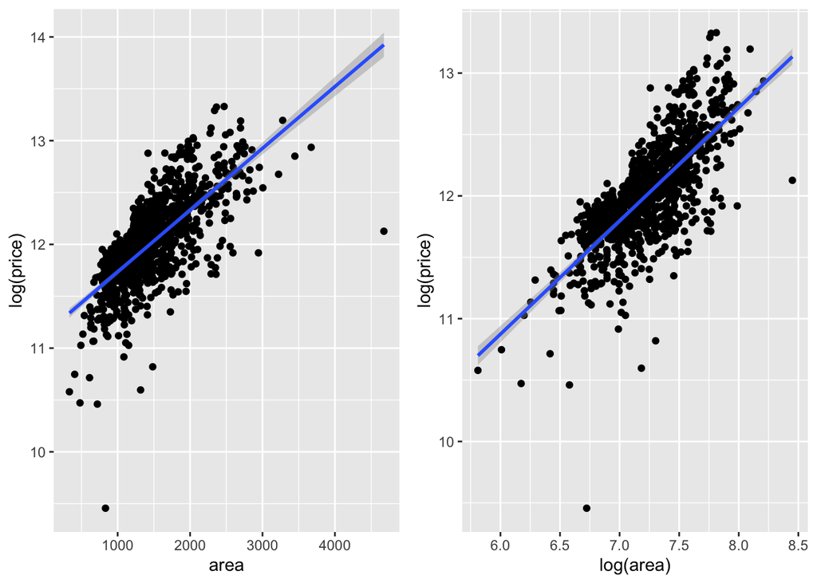

```r
p1 <- ggplot(ames_train, aes(x=area, y=log(price))) +
  geom_point() +
  geom_smooth(method=lm)

p2 <- ggplot(ames_train, aes(x=log(area), y=log(price))) +
  geom_point() +
  geom_smooth(method=lm)

grid.arrange(p1, p2, nrow = 1)
```

As it can be seen the variability is lower with the log(area) transformation. This is more evident for large area houses, were the distribution of area vs houses may indicate that after certain area values, the price is not strongly correlated by the latter.

### Section 3.3 Variable Interaction

Did you decide to include any variable interactions? Why or why not? Explain in a few sentences.

In general terms, variable interactions were avoided. Any interaction among variables are identified as a sign of *collinearity* which should be avoided. However, taking a look at the variables chosen by the model selection process, some intuitions can be done around them. For example, the amount of garage cars (`Garage.Cars`) has some degree of *collinearity* with the house `area`. `Overall.Qual` house condition, might be correlated in some way with the `Year.Built` and the latter with `Year.Remod`.

### Section 3.4 Variable Selection

What method did you use to select the variables you included? Why did you select the method you used? Explain in a few sentences.

Using the BIC elimination process we can determine a model with the highest posterior probability and the probability to include each variable. Compared with a frequentist approach, which can be seen in the summary table of Section 3.1, the bayesian approach give us a model with less variables and a higher posterior distribution, which may translate in a lower risk to overfit the model.

### Section 3.5 Model Testing

How did testing the model on out-of-sample data affect whether or how you changed your model? Explain in a few sentences.

With this in mind, it’s important to say that the data used to train the model doesn’t include all categories for some variables. For so, some data has been removed from the test data as is -at least- not representative.

Finally, in order to achieve a better data fit some outliers in the training data have been removed, particularly the one with high negative residual. Which means that the selling price was well under the estimated one (over-estimated).

Let’s first create our final model to find the residuals and remove them

```r
final_model <- lm(log(price) ~ log(area)+Year.Built+Overall.Qual+
                 Garage.Cars+Neighborhood+MS.Zoning+MS.SubClass+
                 Land.Slope+Condition.1+Condition.2+Lot.Config+Foundation,
                 data=ames_train)
```

Now let’s find the residuals and remove them from the training dataset

```r
min_residual <- which(final_model$residuals < -0.75)
ames_train <- ames_train[-c(min_residual), ]
```

## Part 4 Final Model Assessment

### Section 4.1 Final Model Residual

For your final model, create and briefly interpret an informative plot of the residuals.

Let’s first create the final model based on the identified variables mentioned in the previous paragraphs.

```r
final_model <- lm(log(price) ~ log(area)+Year.Built+Overall.Qual+
                 Garage.Cars+Neighborhood+MS.Zoning+MS.SubClass+
                 Land.Slope+Condition.1+Condition.2+Lot.Config+Foundation,
                 data=ames_train)

summary(final_model)
```

```
##
## Call:
## lm(formula = log(price) ~ log(area) + Year.Built + Overall.Qual +
##     Garage.Cars + Neighborhood + MS.Zoning + MS.SubClass + Land.Slope +
##     Condition.1 + Condition.2 + Lot.Config + Foundation, data = ames_train)
##
## Residuals:
##      Min       1Q   Median       3Q      Max
## -0.61002 -0.06869  0.00270  0.07240  0.53518
##
## Coefficients:
##                       Estimate Std. Error t value Pr(>|t|)
## (Intercept)          0.0350342  0.9871090   0.035 0.971695
## log(area)            0.5178595  0.0249725  20.737  < 2e-16 ***
## Year.Built           0.0036498  0.0004658   7.835 1.29e-14 ***
## Overall.Qual2        0.1061418  0.1548095   0.686 0.493121
## Overall.Qual3        0.3936224  0.1537746   2.560 0.010635 *
## Overall.Qual4        0.4090065  0.1492007   2.741 0.006239 **
## Overall.Qual5        0.5292949  0.1494034   3.543 0.000416 ***
## Overall.Qual6        0.5878061  0.1503899   3.909 9.97e-05 ***
## Overall.Qual7        0.6398633  0.1513489   4.228 2.60e-05 ***
## Overall.Qual8        0.7252846  0.1523904   4.759 2.26e-06 ***
## Overall.Qual9        0.9273179  0.1548563   5.988 3.04e-09 ***
## Overall.Qual10       0.9287471  0.1612219   5.761 1.14e-08 ***
## Garage.Cars          0.0490192  0.0089170   5.497 5.00e-08 ***
## NeighborhoodBlueste  0.1150231  0.0977591   1.177 0.239662
## NeighborhoodBrDale  -0.0082079  0.0740542  -0.111 0.911770
## NeighborhoodBrkSide  0.0788142  0.0600077   1.313 0.189377
## NeighborhoodClearCr  0.0912802  0.0626168   1.458 0.145250
## NeighborhoodCollgCr -0.0142558  0.0464697  -0.307 0.759084
## NeighborhoodCrawfor  0.1554034  0.0541985   2.867 0.004235 **
## NeighborhoodEdwards -0.0439315  0.0507407  -0.866 0.386825
## NeighborhoodGilbert -0.0332103  0.0492045  -0.675 0.499882
## NeighborhoodGreens   0.1505144  0.0826044   1.822 0.068764 .
## NeighborhoodGrnHill  0.5549733  0.1058164   5.245 1.95e-07 ***
## NeighborhoodIDOTRR   0.0194612  0.0655419   0.297 0.766589
## NeighborhoodMeadowV  0.0067513  0.0690002   0.098 0.922077
## NeighborhoodMitchel  0.0148223  0.0502969   0.295 0.768292
## NeighborhoodNAmes    0.0171486  0.0493963   0.347 0.728549
## NeighborhoodNoRidge  0.1069639  0.0520867   2.054 0.040301 *
```

[output cut: 44 more lines]

```
## Condition.2RRNn      0.0075940  0.1700847   0.045 0.964397
## Lot.ConfigCulDSac    0.0366062  0.0201658   1.815 0.069811 .
## Lot.ConfigFR2       -0.0197491  0.0261755  -0.754 0.450751
## Lot.ConfigFR3       -0.0811648  0.0619995  -1.309 0.190822
## Lot.ConfigInside    -0.0101367  0.0120295  -0.843 0.399644
## FoundationCBlock    -0.0108464  0.0202233  -0.536 0.591859
## FoundationPConc      0.0078540  0.0224076   0.351 0.726040
## FoundationSlab      -0.1227512  0.0467184  -2.627 0.008746 **
## FoundationStone      0.0892858  0.0817401   1.092 0.274983
## ---
## Signif. codes:  0 '***' 0.001 '**' 0.01 '*' 0.05 '.' 0.1 ' ' 1
##
## Residual standard error: 0.1331 on 915 degrees of freedom
## Multiple R-squared:  0.9044, Adjusted R-squared:  0.8961
## F-statistic: 108.2 on 80 and 915 DF,  p-value: < 2.2e-16
```

Now let’s plot the residuals

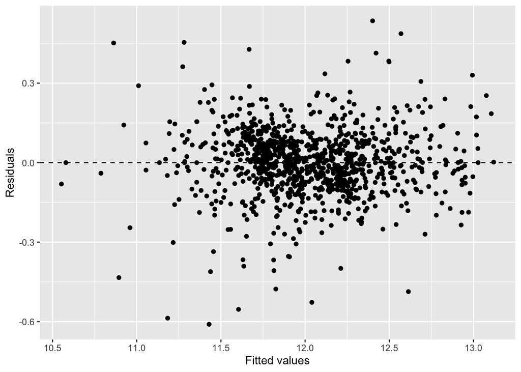

```r
ggplot(data = final_model, aes(x = .fitted, y = .resid)) +
  geom_point() +
  geom_hline(yintercept = 0, linetype = "dashed") +
  xlab("Fitted values") +
  ylab("Residuals")
```

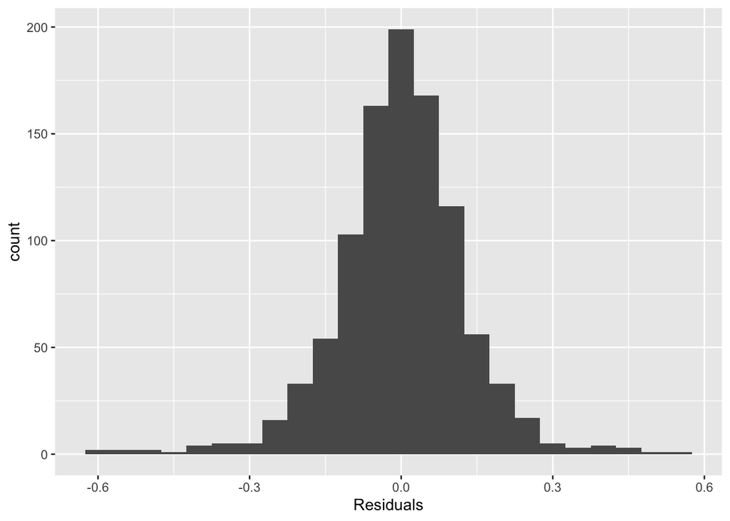

```r
ggplot(data = final_model, aes(x = .resid)) +
  geom_histogram(binwidth = .05) +
  xlab("Residuals")
```

From the plots above it’s clear that the residuals are well balanced around 0. This is a good indication of our final model fit.

### Section 4.2 Final Model RMSE

For your final model, calculate and briefly comment on the RMSE.

As we did before, due that the training dataset does not include the whole set of observables for some variables, the ones which were not trained will have to be removed from the test dataset

```r
ames_test <- subset(ames_test, Neighborhood!='Landmrk')
ames_test <- subset(ames_test, Condition.2 !='RRAn')
ames_test <- subset(ames_test, Exterior.2nd != 'AsphShn')
ames_test <- subset(ames_test, Exterior.2nd != 'Stone')
ames_test <- subset(ames_test, Foundation != 'Wood')

test_predictions<- predict(final_model, ames_test, estimator="HPM")

# Extract Residuals
test_residuals <- ames_test$price - test_predictions

# Calculate RMSE

test_rmse <- sqrt(mean(test_residuals^2))
test_rmse
```

```
## [1] 194388.4
```

```r
postResample(pred=test_predictions, obs=ames_test$price)
```

```
##         RMSE     Rsquared          MAE
## 1.943884e+05 8.001079e-01 1.801886e+05
```

With this results in mind, a summary table can be provided to compare the performance of the test dataframe with the baseline and the full model.

[output not shown]

### Section 4.4 Final Model Validation

Testing your final model on a separate, validation data set is a great way to determine how your model will perform in real-life practice.

You will use the “ames_validation” dataset to do some additional assessment of your final model. Discuss your findings, be sure to mention:

- What is the RMSE of your final model when applied to the validation data?
- How does this value compare to that of the training data and/or testing data?
- What percentage of the 95% predictive confidence (or credible) intervals contain the true price of the house in the validation data set?
- From this result, does your final model properly reflect uncertainty?

Just like we did above, we need to make sure that the validation set has the same variables, variable names, factor levels, etc. as the training and test data sets. Our cleanup follows the same procedure.

```r
load("ames_validation.Rdata")
```

We’ll also remove the categories not present in the training dataset

```r
ames_validation <- subset(ames_validation, MS.SubClass != 150)
ames_validation <- subset(ames_validation, Exterior.1st != 'CBlock')
ames_validation <- subset(ames_validation, Exterior.1st != 'PreCast')
ames_validation <- subset(ames_validation, Condition.2 != 'RRAe')
ames_validation <- subset(ames_validation, Foundation != 'Wood')


validation_predictions <- predict(final_model, ames_validation, estimator="HPM")

# Extract Residuals
validation_residuals <- ames_validation$price - validation_predictions

# Calculate RMSE
test_rmse <- sqrt(mean(validation_residuals^2, na.rm=TRUE) )
test_rmse
```

```
## [1] 184952.1
```

```r
postResample(pred=validation_predictions, obs=ames_validation$price)
```

```
##         RMSE     Rsquared          MAE
## 1.849521e+05 8.150860e-01 1.722465e+05
```

And just to update our table with the validation dataset results

[output not shown]

Now we’ll answer the percentage of the 95% predictive confidence interval containing the true price of the house in the validation data set.

```r
valid_preds <- as.data.frame(predict(full_model, newdata = ames_validation,
        interval = "predict", level = 0.95))

acc <- sum(log(ames_validation$price) >= valid_preds$lwr & log(ames_validation$price) <= valid_preds$upr)/length(ames_validation$price)
acc
```

```
## [1] 0.9774834
```

## Part 5 Conclusion

Provide a brief summary of your results, and a brief discussion of what you have learned about the data and your model.

The data used in this project was interesting since it was real (instead of some made-up nonsensical data). I can certainly imagine working on large, complex data sets like this. Having used this kind of dataset makes me feel better prepared for real world challenges.